# Pesticide Labels Now Report

Draft

2022-04-01

# How do user characteristics inform or explain their interaction with the ‘Pesticides Labels Now’ application?

## Authors: Aarti Tandon, Eddie Kasner, Kit Galvin, Pablo Palmández

# Introduction

Hi! My name is Aarti Tandon and I am currently working as an Undergraduate Research Assistant here at the University of Washington. I work with the Pacific Northwest Agricultural Safety and Health Center under the mentorship of Dr. Eddie Kasner and Kit Galvin. This is my markdown file that I have been working on this past year where I have analyzed data from the ‘Bilingual Health and Safety Messaging’ application. My research is focused on reducing the gaps in fair and equal access for marginalized peoples by understanding our user audience and their preferences for app utility. While working on the app, I have been able to stand at the crossroads of technology and human health. Using the tools of statistics and data visualization, I have contributed to research translation and the improvement of human health, environmental resilience, and social and economic equity.

# Executive Summary

# Objective

## To understand the ‘Pesticide Labels Now’ mobile application user audience and their preferences for app utility.

# Features to Help Understand User Characteristics

- Location
- Device
- Language

# Data Subsets

A data dictionary and descriptive statistics were prepared based on the Pesticide Labels Now (PLN) [analysis plan](https://docs.google.com/document/d/1mUHPYdpWljCWroODGenUjYlyae2ZWwqN4MScBLXlr2U/edit). For a better representation of users, we ignored a list of random identifiers (‘aid’ in *ignores.csv*) associated with the project team members and generated descriptive statistics for three subsets:

- evDownload.01
- evStart
- evViewPage.01

# Descriptive Statistics

# App Use By Location

## Plot for US Sessions

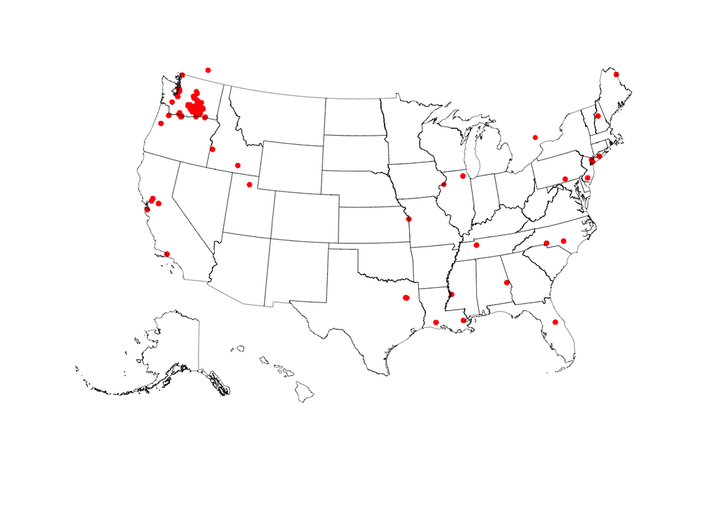

In the United States, user utilization is predominantly concentrated in Washington, however, there is scattered usage throughout the Eastern coast and California.

[output not shown]

## Plot for WA sessions with County Names

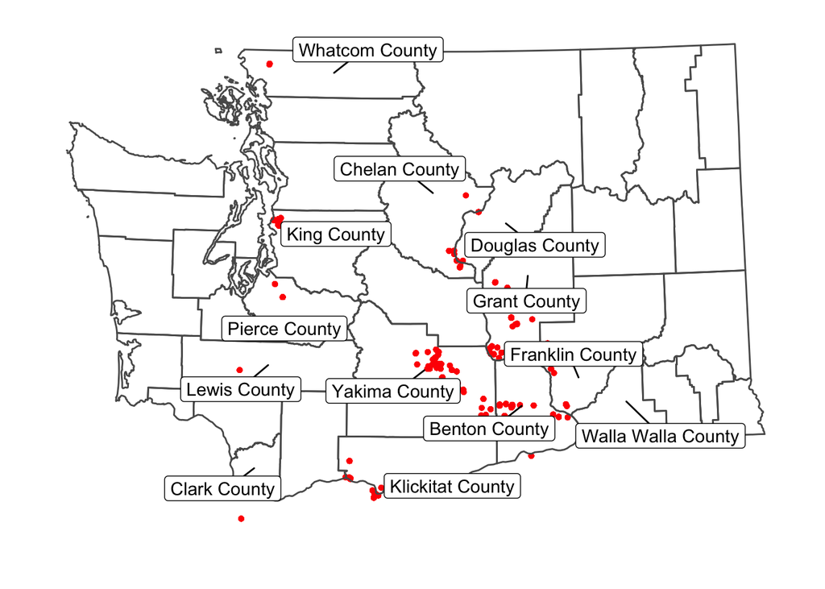

User utilization is predominantly concentrated in central Washington, which is part of the Columbia Basin, and has very productive agricultural land.

# App Use by Device

## Devices Utilized to Access the Application

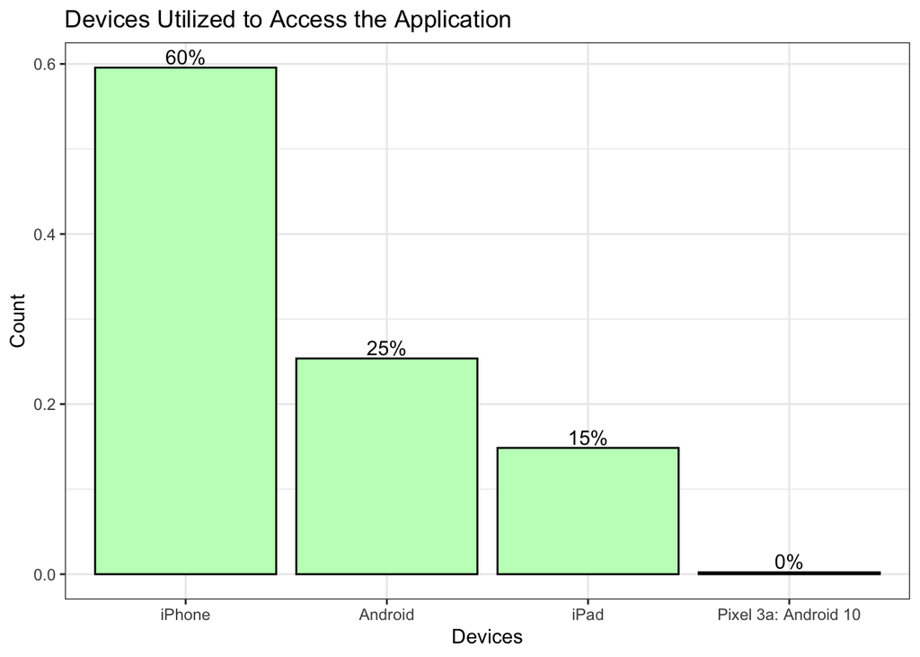

The three devices utilized to access the application were an iPhone, Android, or iPad. Almost 75% of users were accessing the app through an iOS system (e.g. iPhone, iPad) and 25% of users were accessing the app through an Android system.

# App Use by Language

## Frequency of Each Language Accessed on the Application

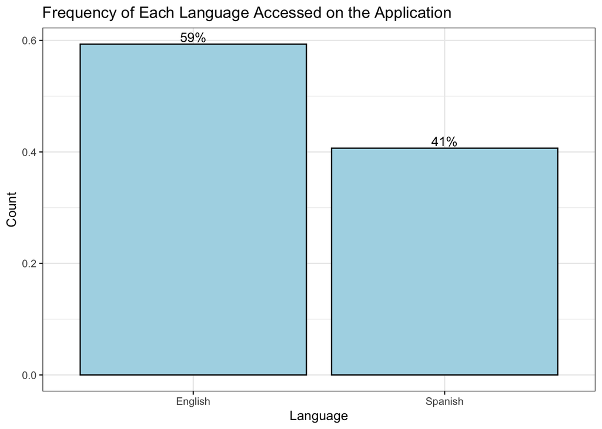

## Frequency of Different Languages by Operating System

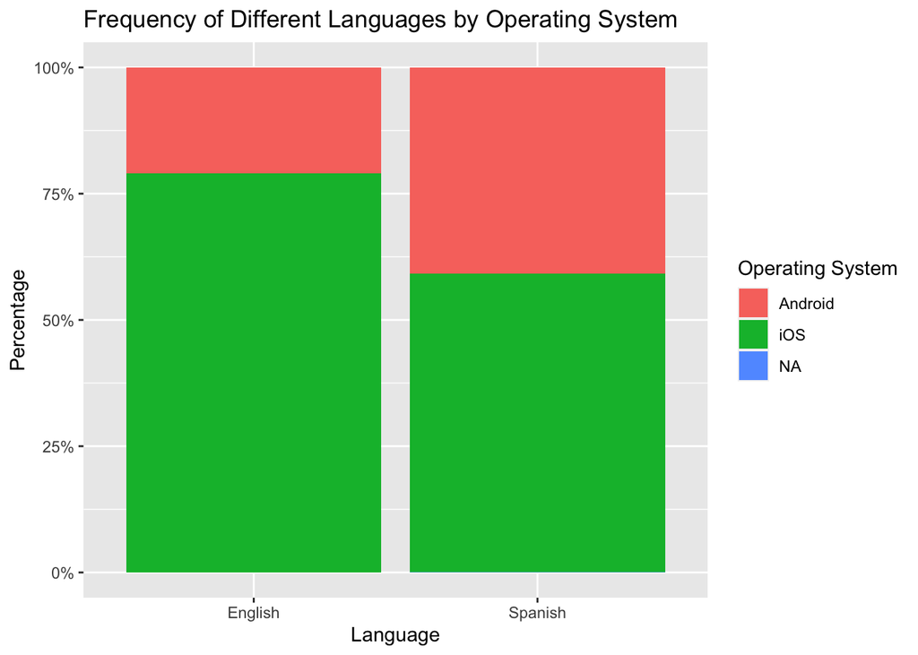

iOS users are more likely to access the information in English than Spanish. Android users are more likely to access the information in Spanish than English. This raises the question why Spanish-speaking users are more likely to have an Android device.

# App Use By Time

## Comparing User Sessions by ‘Day of the Month’, ‘Month’, and ‘Activity of the User’

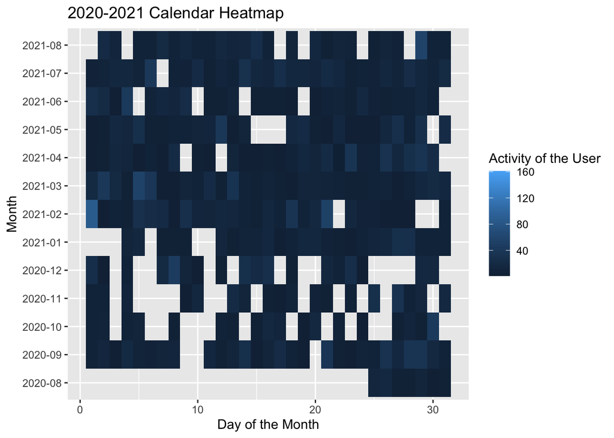

## Comparing User Sessions by ‘Hour of the Day’, ‘Day of the Month’, and ‘Activity of the User’

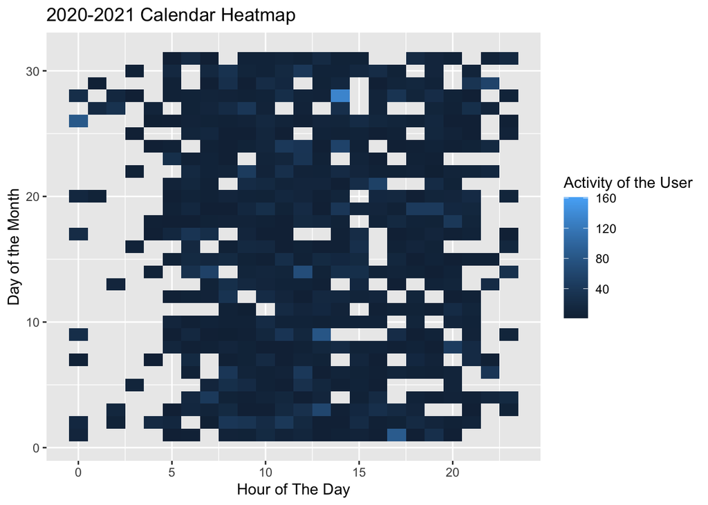

## Comparing User Sessions by ‘Month’, ‘Day of the Month’, and ‘Session Time (in minutes)’

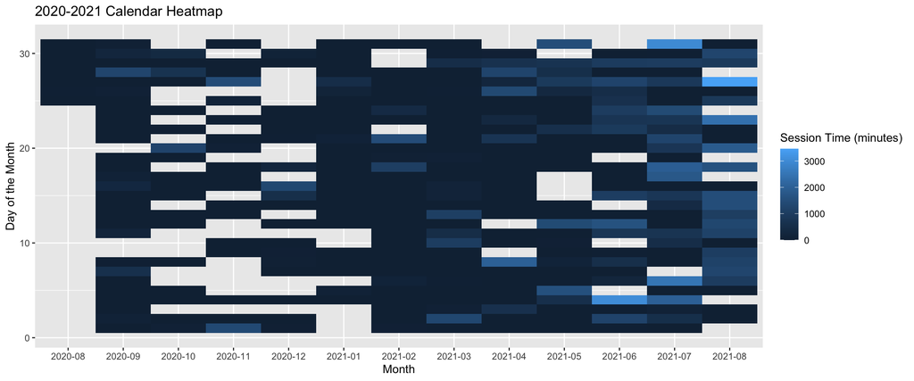

After making changes… it makes sense that from april-august, the app is more utilized

## Comparing User Sessions by ‘Hour of the Month’, ‘Day of the Month’, ‘Month’, and ‘Year’

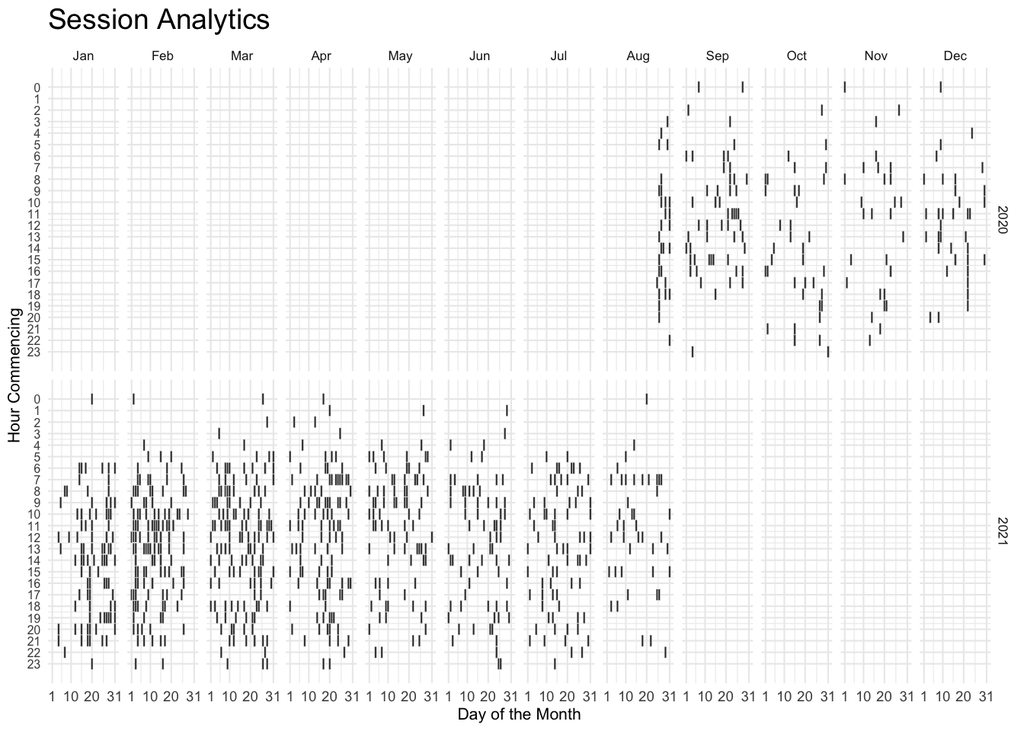

# App Use By Activity

## Frequency of Each Source Page Accessed on the Application

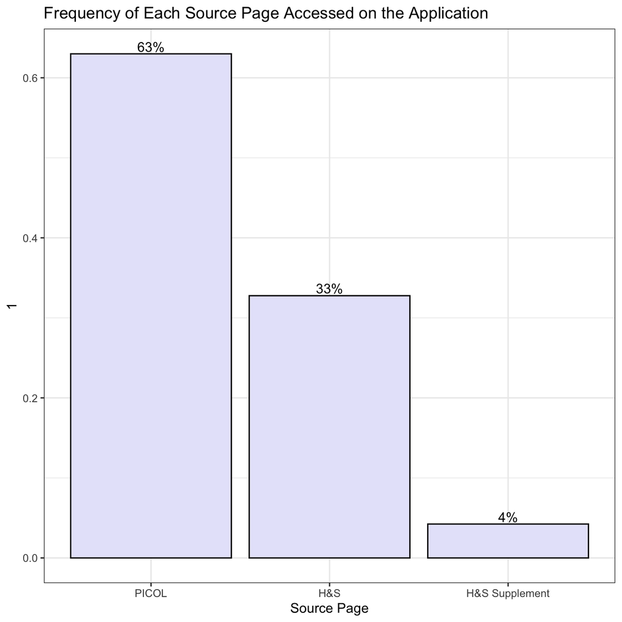

‘PICOL’ can be notably distinguished as the most popular source page accessed by users.

## Activity in Each Label Section

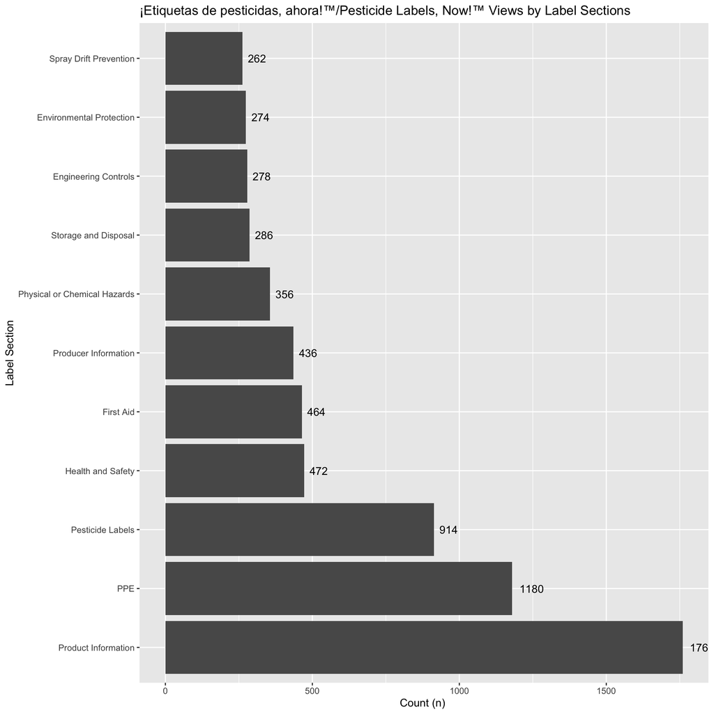

The frequency of each ‘Label Section’ item accessed on the ‘Pesticides Labels Now’ application was analyzed. ‘Product Information’, ‘Personal Protective Equipment’ and ‘Pesticide Labels’ are the most popularly accessed sections by users.

## Frequency of Links Utilized

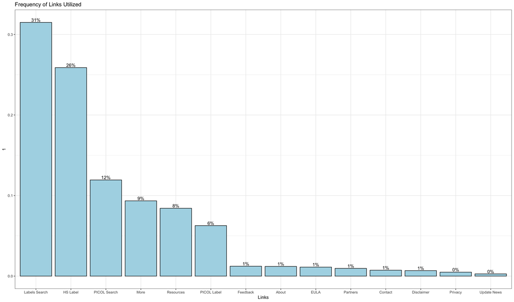

The frequency of each ‘Link’ accessed on the ‘Pesticides Labels Now’ application was analyzed. ‘Labels Search’ was the most popularly viewed section by all users.

## Frequency of Different Links by Language

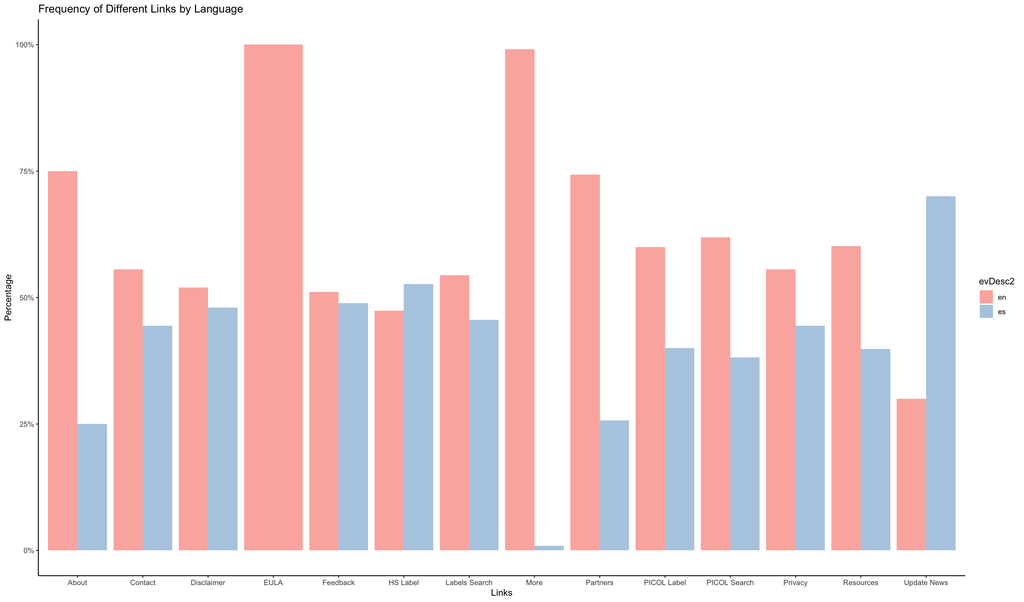

The frequency of each Link accessed on the ‘Pesticides Labels Now’ application was compared to the user’s accessed language. ‘EULA’ was most popularly accessed by English readers and ‘Update News’ was most popularly accessed by Spanish readers.

## Table of Top Ten Searched Pesticides

| Var1 | Freq |
| --- | --- |
| Lorsban® Advanced | 23 |
| PARAQUAT 43.2% SL | 18 |
| 2,4-D AMINE 4 HERBICIDE | 16 |
| 2,4-D /AMINE 4 HERBICIDE | 14 |
| Lorsban®-4E Insecticide | 12 |
| 440 SUPERIOR SPRAY OIL | 11 |
| Delegate® WG | 11 |
| Carbaryl 4L | 10 |
| ABBA ULTRA MITICIDE/INSECTICIDE | 9 |
| 440 Superior Spray Oil | 8 |

Amongst 129 total pesticides in the application, Table 1 displays the top ten searched pesticides. ‘Lorsban® Advanced’ was the most popularly looked at pesticide among users from August 2020-2021.

# Average Session Duration

## 90.11 minutes

# Data Dictionary

## evDownload.01 subset

Unique devices (aid)

```
## [1] 93
```

| Variable | Description |
| --- | --- |
| aid | Random device identifier |
| epaReg | EPA regsistration number |
| prodName | Pesticide product name |
| sourcePage | App page visited? |
| evType | Action taken on app (download) |
| ts | Timestamp yyy:mm:dd:hh:mm:ss |

## evStart subset

Unique users (aid)

```
## [1] 392
```

| Variable | Description |
| --- | --- |
| aid | Random device identifier |
| evDesc1 | App version? |
| evDesc2 | Device type |
| evDesc3 | GPS coordinates |
| evType | Action taken on app (start page) |
| ts | Timestamp yyy:mm:dd:hh:mm:ss |

## evViewPage.01 subset

Unique users (aid)

```
## [1] 358
```

| Variable | Description |
| --- | --- |
| aid | Random device identifier |
| evDesc1 | First action on app |
| evDesc2 | English or Spanish |
| evDesc3 | Pesticide label viewed |
| evType | Action taken on app (view page) |
| ts | Timestamp yyy:mm:dd:hh:mm:ss |

## Detailed variable descriptions

- Device = identified by a randomly assigned identifier. = Person. Person = device. There is no way to distinguish individual users. One device can be used by ≥ 1 person and 1 person can use ≥ 1 device.
- Access = accessed app = put PLN on device and opened app (app opens to label List).
- Session = time from when the app opened until just before next time it is opened.
- PICOL Searches = PICOL results viewed.
- Label searches = Label menu viewed.
- View = accessed and viewed information (any combination of ≥ 1 of the following)
- Label view = accessed + [(opened ≥ 1 label) + (opened ≥ 1 menu bar)] Label view + PDF = accessed + [(opened ≥ 1 label) + (opened ≥ 1 menu bar)+ (downloaded label PDF)]
- PICOL view = accessed + [(conducted ≥ 1 PICOL search) + (viewed ≥ 1 PICOL result)]
- PICOL view + PDF = accessed app + [(conducted ≥ 1 PICOL search) + (viewed ≥ 1 PICOL result) + (downloaded app)]
- General view = accessed +(viewed label search page + selected a label, but did not open menu bar) and/or ( viewed PICOL search page) and/or viewed more pages General view + links
- Location = GPS coordinates. de-identified location in that it is somewhere within the ~ 500 ft radius. We will only report by broad areas. Agricultural regions if they are defined. Currently, many iPhone users are declining location as Apple is asking users if they want the location turned on/off with each update. We may only be able to evaluate this up to the April release date. App is only available to devices registered in the US, CA, and MX. However, phones registered in these countries can be used anywhere. For example, we had a user connect from S. America from a US registered phone.
- Population A definition: anyone that has accessed the app. There is 1 excluded population and 3 study subpopulations (based on gps location coordinates at time the app is opened.)
  - Device used in WA state GPS data. (Not Seattle or King County)
  - Device used outside of WA state
  - No location (location services are off.)
  - Exclude. King County or at least the Seattle metropolitan area locations. These are likely team and PNASH staff. Exclusion list. Selected random devices IDs are on an exclusion list. These are test devices.
- Population B definition: (Only use if enough people respond to in app questions). Those users that respond to the location in-app question. (This response can be linked to app analytic data as it has the same random unique ID). This will be implemented very soon.
  - Response I work in WA state (not quite the same as where they downloaded it)
  - Response I work outside of Washington state
  - Do not want to answer
  - Skips answering the question. (will combine with c)